# Psychometrics Analyses of LLM benchmark data

Author

Tom, Aron, Julius

# Notes

```r
## global variables:
# only if needed
```

# Theory

## Lines of arguments

**Contradictions in the fields of Psychology <-> Machine Learning:**

From my perspective, particularly within specific sub-disciplines of Psychology, the primary objective of statistical methods is to elucidate psychological mechanisms. For instance, in Experimental Psychology (Allgemeine Psychologie), researchers manipulate specific experimental conditions (independent variables) and measure the effects of these manipulations, ideally within randomized controlled trials (RCTs). Disciplines like Machine Learning, prioritize however prediction. Despite these differences, both fields can benefit from one another, as highlighted by Yarkoni and Westfall (2017).

> Psychology has historically been concerned, first and foremost, with explaining the causal mechanisms that give rise to behavior. Randomized, tightly controlled experiments are enshrined as the gold standard of psychological research, and there are endless investigations of the various mediating and moderating variables that govern various behaviors. We argue that psychology’s near-total focus on explaining the causes of behavior has led much of the field to be populated by research programs that provide intricate theories of psychological mechanism but that have little (or unknown) ability to predict future behaviors with any appreciable accuracy. We propose that principles and techniques from the field of machine learning can help psychology become a more predictive science. We review some of the fundamental concepts and tools of machine learning and point out examples where these concepts have been used to conduct interesting and important psychological research that focuses on predictive research questions. We suggest that an increased focus on prediction, rather than explanation, can ultimately lead us to greater understanding of behavior.

However, an intense focus on prediction - especially when applying “black box” models - could spark criticism within the field. Potential critiques include:

- Lack of Interpretability: Black box models often provide little to no insight into the underlying mechanisms driving predictions, which contradicts the psychological emphasis on understanding (causal) relationships.
- Theoretical Disconnect: Machine learning models may not align with (or care of) established psychological theories, leading to a fragmentation between predictive accuracy and theoretical coherence.
- Ethical Concerns: The deployment of predictive models without a clear understanding of their decision-making processes can lead to ethical dilemmas, particularly in areas such as clinical psychology.
- …

Combing methods from multiple fields it is possible to adopt a more integrative approach, when investigating research questions/ analyzing data: it is possible to categorize types of research questions and their corresponding statistical models (e.g., EFA for exploration, ANOVA in context of an RCT to discover a “causal” effect, machine learning to maximize prediction, cluster analyses for identifying homogeneous subgroups,…) and every method can give important insights:

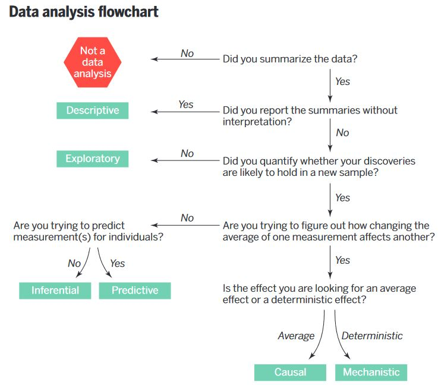

Data Analysis Flowchart by Leek and Peng (2015)

Contrary to the perception of data analysis as a linear process, it is inherently a highly iterative process where insights gained at each step lead to re-evaluating and refining previous steps before moving forward. This cyclical approach ensures continuous learning and adjustment, in contrast to a seemingly straightforward, linear application of specific statistical models like a cooking recipe:

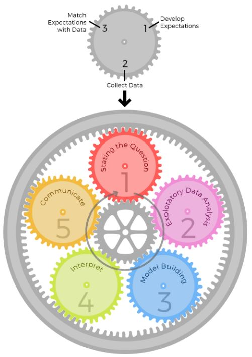

Epicycles of Analysis by Peng and Matsui (2016)

To summarize, in my opinion several factors may contribute to the (at least implicit or often pragmatic driven) rejection of methodologies from other fields and their respective “research philosophies”. These factors reflect both structural and cultural pressures within academia:

- **Pressure and Working Conditions in Academia**: Researchers, particularly early-career scientists, face significant pressure to “publish or perish,” often under challenging working conditions. For example:
  - In Germany, as reported by Konsortium Bundesbericht Wissenschaftlicher Nachwuchs (2021), approximately 90% of early-career researchers are employed on fixed-term contracts, with PhD students averaging contract lengths of only 22 months. Further despite a strong desire to start families, particularly among women, career uncertainties, poor work-life balance, and financial instability are mentioned as key reasons for the high rate of childlessness among young female researchers (see also Sengewald et al. 2024)
  - Internationally, similar challenges have been highlighted in recent work, such as Rahal et al. (2023), which discusses ways to redesign academic systems, emphasizing the role of permanent employment
- **Conservatism in Methodology**: A common response to the pressure to “publish or perish” is to adhere to familiar statistical models, technological tools, and the prevailing working styles of one’s research group. This methodological conservatism helps reduce the risks associated with exploring unfamiliar or cross-disciplinary approaches, but it may limit innovation and interdisciplinary collaboration. Next to limited contracts and insecure working conditions, this methodological rigidity could also be explained by multiple sociological theories:
  - Bourdieu’s Theory of Fields suggests that the academic field operates under specific power dynamics, where certain styles of working gain dominance based on their alignment with the interests of those in power (in the center of the field). Further academics feel pressure to conform to established norms within their discipline (Fligstein and McAdam 2015), see also YouTube Video [” Field theory - Pierre Bourdieu”](https://www.youtube.com/watch?v=7FXPnkwSCyE)
  - Luhmann’s Theory of the Differentiation of Social Systems posits that academia, like other social systems, differentiates itself through specialized methodologies that reinforce the boundaries between disciplines (Luhmann 1987)
  - Historical factors, including power-related dynamics, also play a role. For instance, Wallerstein’s work on European Universalism discusses how power structures have historically influenced which ideas and methodologies become dominant in different fields (Wallerstein 2006)

## brief theory of latent variable models

In context of answering survey question the Cognitive Aspects of Survey Methodology (also called „Optimizing-Satisficing-Model“) tries to explain how people finally arrive at a response, which is a great heuristic for identifying possible sources of error (Tourangeau, Rips, and Rasinski 2000,; Moosbrugger and Kelava 2020):

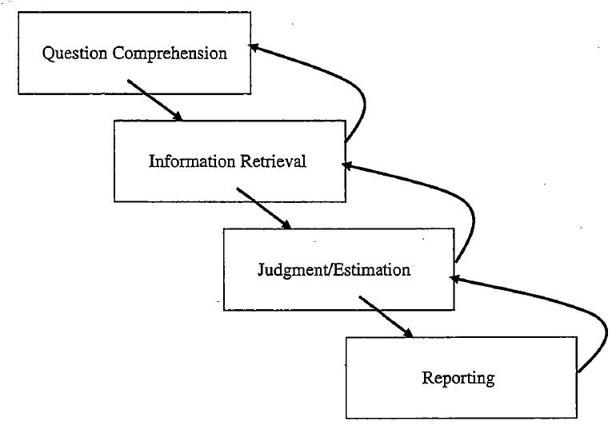

Cognitive Aspects of Survey Methodology

Despite not knowing the exact processes of answering a question (black box), we fundamentally assume that the answer / reporting depends on a **score on a latent variable**:

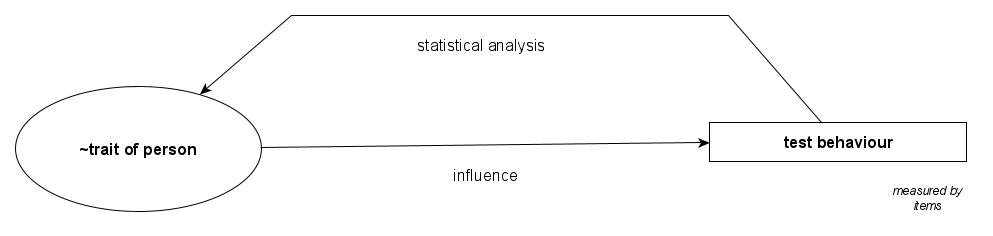

> the central task of test theory is to determine the relationship between test behaviour and the (psychological) characteristic to be assessed

**Latent variable definition**: random variables whose realized values are hidden (Bollen 2002; Borsboom 2008)

A possible operationalisation of a latent variable is a linear measurement model with the equation $Y = \lambda * \eta + \epsilon$.

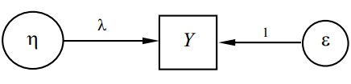

basic measurment model

this corresponds to the fundamental equation of Classical Test Theory:
$$Y = T + \epsilon$$

$\rightarrow$ models which are dealing with latent variables are called **Latent Variable Models** (Skrondal and Rabe-Hesketh 2004, 2007), whereby the central aim of latent variable models is to infer unobservable (latent) psychological traits or abilities from responses to test items

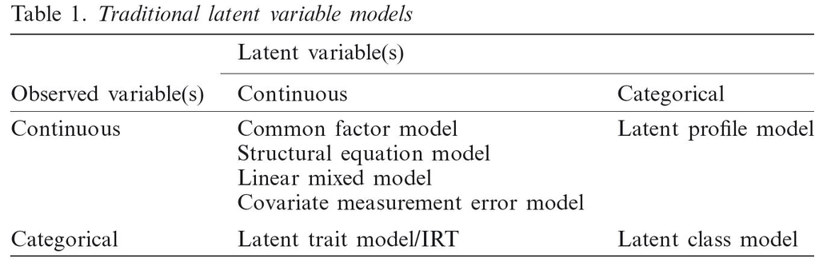

Latent variable models Skrondal and Rabe-Hesketh (2007)

**theoretical aspects “What is a Latent Variable?”**

- the theoretical status of latent variables has not been clarified (Schurig 2017)
  - are these variables representations of real entities or just useful inventions?
  - Advantage: use of latent variables allow more generalisable reasoning than manifest variables
- latent variables need a substantive scientific foundation, whereby the bridging problem between observed and latent variable must be solved by theoretical assumptions and statistical modelling

centrally by assuming the **local independence assumption** in latent variable models it is assumed that, once the latent variable (e.g., a psychological trait or ability) is accounted for, the observed variables (such as responses to test items) are statistically independent of each other. This means that any correlation between the observed variables is fully explained by the latent variable, and no further direct relationships exist between the observed variables. In essence, the latent variable “absorbs” the shared variance, allowing the model to “get rid” of any inter-dependencies among the observed variables, simplifying the analysis (Skrondal and Rabe-Hesketh 2007).

$$Pr(y_j \mid \eta_j) = \prod_{i=1}^{n} Pr(y_{ij} \mid \eta_j)$$

This assumption do not hold in more complex data sets (e.g., multi-dimensionality, response styles, …) and by more complex models (e.g., the bifactor model) the variance of indicators of single measurment models (CFAs) is divided into common and unique variance:

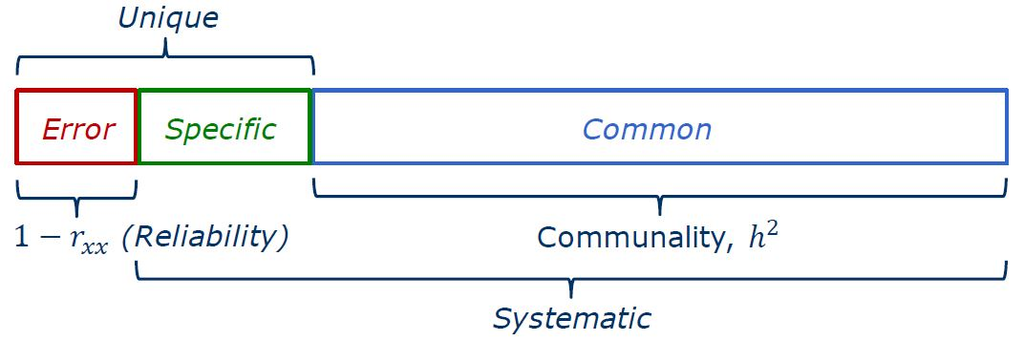

Variance splitting in CFAs

The variance shared between the indicators is the commonality; the remaining variance is the unique variance, which is divided into indicator-specific method variance (specific) and measurement variance (error).

**quality criteria of measurments**

measurements, test administration should be carried out taking into account three central quality criteria of tests, which build on each other (no reliable measurement possible without objectivity, etc.):

$$\text{objectivity} \rightarrow \text{reliability} \rightarrow \text{validity}$$

Importantly more recently there is also an **argument-based approach to validation**. To validate an interpretation or use of measurements is to evaluate the rationale, or argument, for the proposed conclusions and decisions … Ultimately, the need for validation derives from the scientific and social requirement that public claims and decisions need to be justified:

- *interpretive argument*: specifies the proposed interpretations and applications of assessment results by laying out a network of inferences and assumptions leading from the observed performances to the conclusions and decisions based on the assessment scores
- *validity argument*: provides an evaluation of the interpretive argument’s coherence and the plausibility of its inferences and assumptions

A variety of further quality criteria of indicators were developed by the **„Key National Indicators Initiative“** (outdated, ~ 2005):

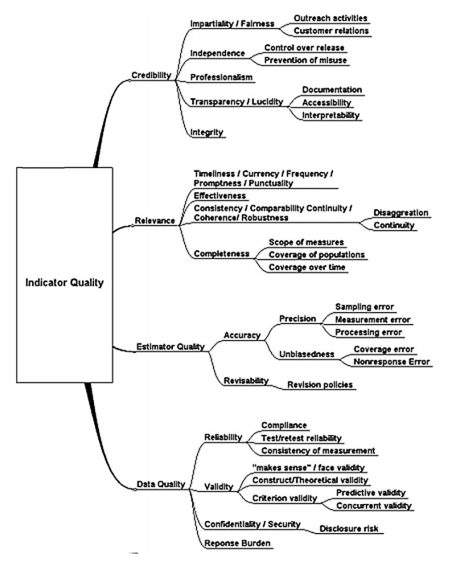

Key National Indicators Initiative, by Groves and Lyberg (2010)

To reflect on all possible factors influencing the quality of a survey, there is also the concept of the **Total Survey Error** (see Biemer et al. 2017; Groves and Lyberg 2010).

## assumptions 1PL, 2PL model

Before running any statistical model, normally - if model is sensitive to the violation of a specific assumption - the assumptions of the models are tested; for the Raschmodell (1PL) we have the following assumptions (aus Julius Masterarbeit):

- Eindimensionalität: Die Lösungswahrscheinlichkeit hängt nur von einem latenten Merkmal ab und ist durch die Modellparameter $\theta_v$, $\beta_i$ bestimmt. Neben den Modellparametern liegen keine weiteren beeinflussenden Variablen $\varphi$ vor: $P(X_{vi} = 1 \mid \theta_v, \beta_i, \varphi) = (X_{vi} = 1 \mid \theta_v, \beta_i)$
- Lokale stochastische Unabhängigkeit: Wenn die Personenfähigkeit $\theta_v$ auf einem Wert konstant gehalten wird, verschwindet die Korrelation zwischen jedem möglichen Itempaar $X_{vi}$, $X_{vj}$ im Test (wobei $i \neq j$): $P(X_{vi} \perp X_{vj} \mid \theta_v), \forall \,\, i, j$
- Suffizienz der Summenscores: Die Summenscores $R_v = \sum_{i=1}^{k} X_{vi}$ eines Tests der Länge $k$ sind ausreichend für die Schätzung der Personenfähigkeit einer Person $\theta_v$. Das Gleiche gilt analog für die Itemscores $C_i = \sum_{v=1}^{n} X_{vi}$
- Monotonie: Die Lösungswahrscheinlichkeit eines Items $x_{vi}$ erhöht sich monoton mit höheren Personenfähigkeitswerten $\theta$. Je fähiger eine Person ist, desto wahrscheinlicher wird diese ein Item beantworten können. Dies drückt sich in der ICC $f(x_{vi} \mid \theta_v, \beta_i)$ wie folgt aus: $\theta_v > \theta_w: f(x_{vi} \mid \theta_v, \beta_i) > f(x_{wi} \mid \theta_w, \beta_i), \forall \,\, \theta_v, \theta_w$

> In the 2PL model, each item has additionally its own discrimination parameter, allowing some items to be better at differentiating between individuals with slightly different abilities.

If now the 1PL or 2PL is not fitting, this could have multiple reasons:

- Multidimensionality, items are influenced by more than one latent trait
- Poorly Fitting Items or Data, some items behave in an unexpected or erratic manner, it may not exhibit the expected increasing probability of a correct response as ability increases, especially if the item discrimnation parameter $\alpha_i$ is estimated negative (Monotonicity violated)
- Ceiling or Floor Effects, test contains items that are either too easy or too difficult for the population being measured, the probability of a correct response might not vary meaningfully with ability over a range of $\theta$ values.
- …

# load packages, data

```r
# sets the directory of location of this script as the current directory
# setwd(dirname(rstudioapi::getSourceEditorContext()$path)) # not needed in Quatro env.

### load packages
```

```
#> This function is a wrapper for library and require. It checks to see if a package is installed, if not it attempts to install the package
```

```r
require(pacman)
p_load('mirt', 'ggplot2', 'dplyr', 'tidyr', 'parallel', 'psych',
       'rpart', 'rpart.plot')

### load, prepare data
setwd("data")
```

```
#> long format
```

```r
data_long <- read.csv("mmlu_data.csv")
data_long <- select(data_long, -"model")
```

```
#> remove items
```

```r
items_to_remove <- data_long %>%
  group_by(doc_id) %>%
  summarize(mean = mean(acc), variance = var(acc))
# any items which are solved by every LLM?
cat("number of items solved by all LLMs:", sum(items_to_remove$mean == 1), "\n")
```

```
number of items solved by all LLMs: 0
```

```r
items_to_remove <- items_to_remove %>%
  filter(variance == 0) %>%
  select(doc_id) %>%
  unlist() %>%
  as.character()

data_long <- data_long %>%
  filter(!doc_id %in% items_to_remove)

cat("number of items which have been removed:", length(items_to_remove), "\n")
```

```
number of items which have been removed: 54
```

```
#> wide format
```

```r
data_wide <- spread(data_long, doc_id, acc)
# data_wide <- select(data_wide, -"model_id")
```

# making one suspicious

## 1PL, 2PL over subsample

over some sets of items the 2PL model **do converge**:

```r
### sub-sample items
set.seed(12345) # to replicate results

setSize <- 30

random_items <- sample(x = 2:ncol(data_wide), size = setSize, replace = FALSE) # first variable is the model id
sub_dat <- data_wide[, random_items]

# Fit 1PL model (Rasch model)
fit1PLa <- mirt(data = sub_dat,
               model = 1,  # one-dimensional model
               itemtype = "Rasch",
               verbose = FALSE)

# Fit 2PL model
fit2PLa <- mirt(data = sub_dat,
               model = 1,  #one-dimensional
               itemtype = "2PL",
               technical = list(NCYCLES = 2000, SEtol = 1e-4),
               verbose = FALSE)


### estimated params
item_parameters_1PL <- coef(fit1PLa, IRTpars = TRUE, simplify = TRUE)$items
item_parameters_2PL <- coef(fit2PLa, IRTpars = TRUE, simplify = TRUE)$items

# item difficulty param "b", item discrimination param "a"
```

```
#> 1PL
```

```r
psych::describe(x = item_parameters_1PL[,c("b", "a")])
```

```
  vars  n mean   sd median trimmed mad   min  max range skew kurtosis   se
b    1 30 1.55 1.55   1.65    1.56 1.5 -1.32 4.45  5.77 0.04    -0.83 0.28
a    2 30 1.00 0.00   1.00    1.00 0.0  1.00 1.00  0.00  NaN      NaN 0.00
```

```
#> 2PL
```

```r
psych::describe(x = item_parameters_2PL[,c("b", "a")])
```

```
  vars  n mean   sd median trimmed  mad    min   max range  skew kurtosis   se
b    1 30 0.08 4.68   0.52    0.47 3.11 -14.87  9.47 24.34 -0.97     1.82 0.85
a    2 30 1.54 3.66   0.71    0.74 1.29  -1.45 14.67 16.13  2.97     7.87 0.67
```

```r
### item fit statistics
# Calculate item fit statistics for the 2PL model
item_fit <- itemfit(fit2PLa)
item_fit[order(item_fit$S_X2),]
```

```
    item   S_X2 df.S_X2 RMSEA.S_X2 p.S_X2
5   4939  1.022       2      0.000  0.600
10  9291  1.383       2      0.000  0.501
16  9201  2.270       1      0.078  0.132
7   2271  2.414       3      0.000  0.491
18  2827  2.590       3      0.000  0.459
23  7817  5.709      10      0.000  0.839
27  2117  5.832       8      0.000  0.666
11  9091  6.009       4      0.049  0.198
6    604  6.616       3      0.076  0.085
24 10145  7.234      10      0.000  0.703
4  10950  7.438       7      0.017  0.385
28 11796 11.206       6      0.065  0.082
8  10027 11.949      11      0.020  0.367
19   392 12.247      11      0.023  0.345
```

[output cut: 16 more lines]

and over some sets of items the 2PL model do **do not converge**:

```r
########
# sub-sample items
########
set.seed(11111) # to replicate results

setSize <- 30

random_items <- sample(x = 1:ncol(data_wide), size = setSize, replace = FALSE)
sub_dat <- data_wide[, random_items]

# Fit 1PL model (Rasch model)
fit1PLa <- mirt(data = sub_dat,
               model = 1,  # one-dimensional model
               itemtype = "Rasch",
               verbose = FALSE)

# Fit 2PL model
fit2PLa <- mirt(data = sub_dat,
               model = 1,  #one-dimensional
               itemtype = "2PL",
               technical = list(NCYCLES = 2000, SEtol = 1e-4),
               verbose = FALSE)
```

```
EM cycles terminated after 2000 iterations.
```

# check assumptions of such models

## check for unidimensionality

to check for the unidimensionality of the data, we can - compute the correlation between the items using the Phi Coefficient - followed by an EFA, whereby parallel analysis is applied to determine the number of factors (see recommendations for such analysis Auerswald and Moshagen 2019)

use only a subset of data, the first variable is the model id:

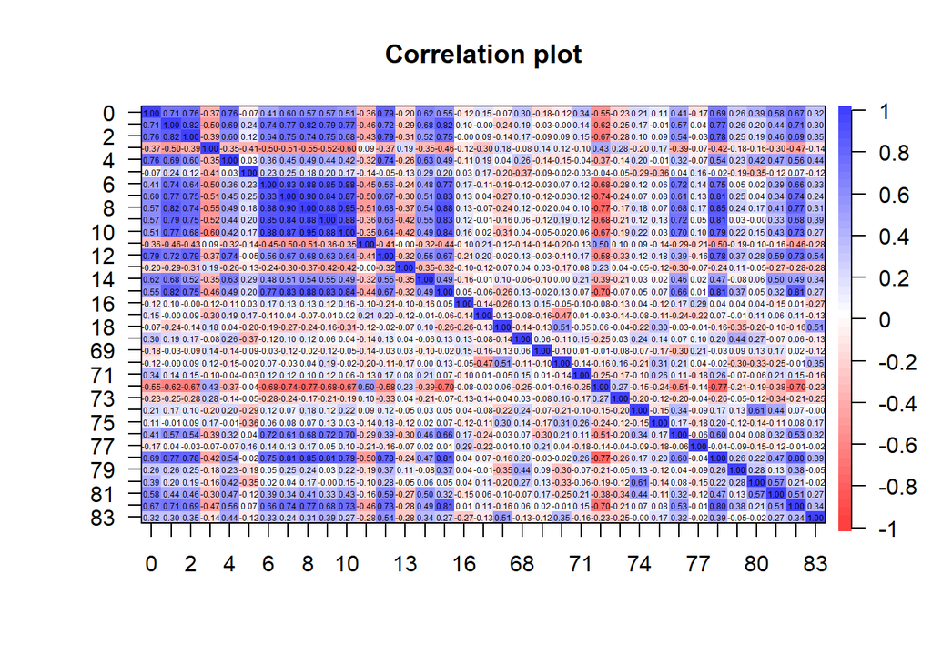

```r
cor_matrix <- cor(data_wide[,c(2:20, 70:85)]) # simply use Phi coefficient

psych::corPlot(r = cor(cor_matrix))
```

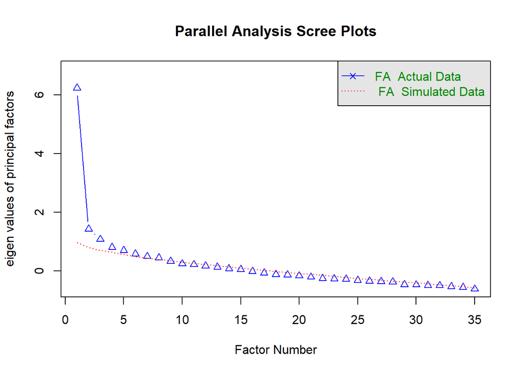

```
Parallel analysis suggests that the number of factors =  8  and the number of components =  NA
```

```r
efa_parallel <- psych::fa.parallel(cor_matrix, fa = "fa", n.obs = nrow(data_wide), cor = "cor")
```

```r
efa_results <- psych::fa(cor_matrix, nfactors = efa_parallel$nfact, fm = "pa")
efa_results
```

```
Factor Analysis using method =  pa
Call: psych::fa(r = cor_matrix, nfactors = efa_parallel$nfact, fm = "pa")
Standardized loadings (pattern matrix) based upon correlation matrix
     PA1   PA2   PA3   PA5   PA4   PA6   PA7   PA8    h2   u2 com
0   0.04  0.50  0.00  0.11  0.09  0.34 -0.17 -0.03 0.588 0.41 2.3
1   0.36  0.51 -0.05  0.04 -0.12  0.07  0.11  0.06 0.562 0.44 2.2
2   0.32  0.30  0.07 -0.01  0.02  0.15 -0.08  0.08 0.380 0.62 2.8
3  -0.25 -0.04  0.14 -0.02  0.16  0.06  0.18  0.12 0.151 0.85 4.1
4  -0.04  0.74  0.13  0.08 -0.02 -0.11 -0.10  0.01 0.625 0.38 1.2
5   0.09  0.16 -0.15 -0.11 -0.65 -0.04 -0.01  0.03 0.468 0.53 1.4
6   0.72 -0.14  0.07  0.15 -0.14  0.04  0.10 -0.01 0.568 0.43 1.3
7   0.65  0.04 -0.06 -0.08 -0.05  0.10 -0.09  0.10 0.493 0.51 1.2
8   0.81  0.04 -0.02  0.05  0.01 -0.03  0.07  0.10 0.701 0.30 1.1
9   0.68  0.10  0.11 -0.11 -0.04  0.09 -0.04 -0.19 0.589 0.41 1.4
10  0.84 -0.05 -0.06  0.08  0.01 -0.11 -0.08 -0.09 0.685 0.31 1.1
11 -0.11 -0.02 -0.09 -0.01  0.03 -0.09 -0.20 -0.30 0.160 0.84 2.6
12  0.23  0.23  0.26  0.15  0.11  0.08 -0.37  0.26 0.678 0.32 5.1
13 -0.13 -0.01 -0.11 -0.01  0.07  0.09  0.08  0.11 0.055 0.94 5.2
14  0.05  0.41  0.13  0.18 -0.32  0.19  0.08 -0.08 0.410 0.59 3.2
15  0.63  0.20  0.00 -0.15  0.04 -0.01  0.04  0.17 0.556 0.44 1.5
16  0.18  0.03 -0.18 -0.02  0.04 -0.05  0.20 -0.02 0.102 0.90 3.3
17 -0.04  0.04 -0.13 -0.05 -0.10  0.00 -0.54 -0.06 0.303 0.70 1.3
18 -0.20  0.08  0.56 -0.01  0.02  0.07  0.09 -0.04 0.354 0.65 1.4
68 -0.01  0.36 -0.21 -0.18  0.41  0.10  0.14  0.04 0.385 0.61 3.4
69  0.00 -0.05 -0.04  0.26  0.01 -0.02  0.25  0.35 0.199 0.80 2.8
70  0.09  0.02  0.44 -0.23  0.05  0.02  0.30 -0.05 0.357 0.64 2.5
71 -0.04 -0.06 -0.14  0.09  0.00  0.63  0.01  0.00 0.391 0.61 1.2
72 -0.37  0.10  0.00 -0.01 -0.09 -0.18  0.00 -0.12 0.202 0.80 2.0
73 -0.03  0.13 -0.02 -0.17  0.05 -0.08  0.10  0.01 0.057 0.94 3.4
74  0.11  0.13 -0.14  0.33  0.28 -0.14  0.06 -0.32 0.390 0.61 4.4
75  0.07 -0.11  0.22 -0.16  0.25  0.29 -0.04 -0.06 0.230 0.77 4.1
76  0.47  0.10  0.10  0.01  0.11  0.07  0.14 -0.36 0.437 0.56 2.5
77  0.11  0.06 -0.02  0.03 -0.10 -0.09  0.27  0.15 0.110 0.89 2.7
78  0.52  0.05  0.07  0.06  0.19  0.21 -0.11  0.12 0.516 0.48 2.0
79  0.12  0.15 -0.19 -0.05  0.29 -0.15 -0.07  0.32 0.315 0.68 4.1
80 -0.04  0.22 -0.14  0.43  0.28 -0.12  0.01 -0.03 0.387 0.61 2.9
81  0.05  0.05  0.05  0.72 -0.01  0.11 -0.02  0.02 0.589 0.41 1.1
82  0.40  0.11  0.06  0.09  0.05  0.07 -0.10  0.21 0.361 0.64 2.2
83  0.09  0.09  0.63  0.08  0.04 -0.17 -0.07  0.03 0.470 0.53 1.3

```

[output cut: 22 more lines]

```
df of  the model are 343  and the objective function was  2.34

The root mean square of the residuals (RMSR) is  0.04
The df corrected root mean square of the residuals is  0.05

Fit based upon off diagonal values = 0.96
Measures of factor score adequacy
                                                   PA1  PA2  PA3  PA5  PA4  PA6
Correlation of (regression) scores with factors   0.96 0.90 0.84 0.84 0.82 0.80
Multiple R square of scores with factors          0.92 0.81 0.71 0.71 0.67 0.63
Minimum correlation of possible factor scores     0.83 0.61 0.41 0.43 0.35 0.27
                                                   PA7  PA8
Correlation of (regression) scores with factors   0.80 0.78
Multiple R square of scores with factors          0.63 0.60
Minimum correlation of possible factor scores     0.27 0.21
```

```r
print(efa_results$loadings)
```

```
Loadings:
   PA1    PA2    PA3    PA5    PA4    PA6    PA7    PA8
0          0.501         0.111         0.344 -0.172
1   0.363  0.508               -0.124         0.107
2   0.323  0.296                       0.148
3  -0.254         0.141         0.161         0.182  0.122
4          0.744  0.133               -0.105
5          0.161 -0.153 -0.110 -0.648
6   0.721 -0.143         0.151 -0.140
7   0.646
8   0.806
9   0.684         0.109 -0.107                      -0.186
10  0.842                             -0.108
11 -0.114                                    -0.203 -0.300
12  0.234  0.227  0.263  0.148  0.114        -0.373  0.255
```

[output cut: 27 more lines]

## num items to num persons

- small simulation study
- unstable if items >> persons

```r
# see: https://www.r-bloggers.com/2012/12/simple-data-simulator-for-the-2pl-model/

twopl.sim         <- function( nitem = 20, npers = 100 ) {

  i.loc         <- rnorm( n = nitem, mean = 0, sd = 1 )
  p.loc         <- rnorm( n = npers, mean = 0, sd = 1 )
  i.slp         <- rlnorm( nitem, sdlog = .4 )

  temp          <- matrix( rep( p.loc, length( i.loc ) ), ncol = length( i.loc ) )

  logits        <- t( apply( temp  , 1, '-', i.loc) )
  logits        <- t( apply( logits, 1, '*', i.slp) )

  probabilities <- 1 / ( 1 + exp( -logits ) )

  resp.prob     <- matrix( probabilities, ncol = nitem)

  obs.resp      <- matrix( sapply( c(resp.prob), rbinom, n = 1, size = 1), ncol = length(i.loc) )

  output        <- list()
  output$i.loc  <- i.loc
  output$i.slp  <- i.slp
  output$p.loc  <- p.loc
  output$resp   <- obs.resp

  output
}
```

$i << n$ (less items than persons/ LLMs):

```r
set.seed(123)
data2pl <- twopl.sim(nitem=300,npers=3000)

# Track time to fit 2PL model
start_time <- Sys.time()

fit2PL <- mirt(data = as.data.frame(data2pl$resp),
               model = 1,  # one-dimensional
               itemtype = "2PL", verbose = FALSE)

end_time <- Sys.time()
fit_time <- end_time - start_time

# Print the time taken to fit the model
cat("Time taken to fit the 2PL model in seconds:", fit_time, "\n")
```

```
Time taken to fit the 2PL model in seconds: 9.550896
```

```r
item_parameters_2PL <- coef(fit2PL, IRTpars = TRUE, simplify = TRUE)$items

# item difficulty param
summary(item_parameters_2PL[,"b"])
```

```
    Min.  1st Qu.   Median     Mean  3rd Qu.     Max.
-2.21305 -0.61690 -0.04756  0.03039  0.64970  3.54400
```

```r
# item discrimination param
summary(item_parameters_2PL[,"a"])
```

```
   Min. 1st Qu.  Median    Mean 3rd Qu.    Max.
 0.2471  0.7974  1.0109  1.0992  1.3207  2.7445
```

```r
layout(matrix(c(1,2),nrow=1))

plot(item_parameters_2PL[,"a"], data2pl$i.slp)
cor(item_parameters_2PL[,"a"], data2pl$i.slp)
```

```
[1] 0.991225
```

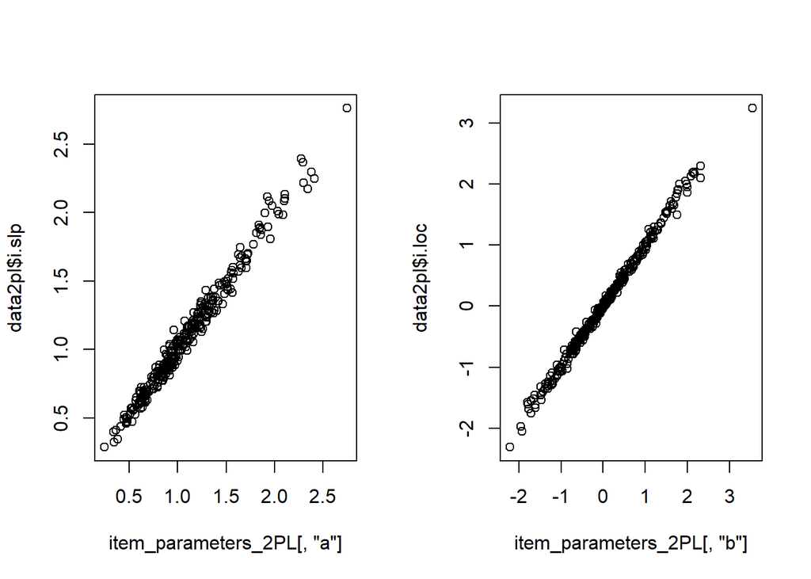

```r
plot(item_parameters_2PL[,"b"], data2pl$i.loc)
```

```r
cor(item_parameters_2PL[,"b"], data2pl$i.loc)
```

```
[1] 0.9976121
```

$i >> n$ (more items than persons/ LLMs):

- here we have the ration 4:1

```r
set.seed(555)
data2pl <- twopl.sim(nitem=800,npers=200)

# Track time to fit 2PL model
start_time <- Sys.time()

fit2PL <- mirt(data = as.data.frame(data2pl$resp),
               model = 1,  # one-dimensional
               itemtype = "2PL", verbose = FALSE)

end_time <- Sys.time()
fit_time <- end_time - start_time

# Print the time taken to fit the model
cat("Time taken to fit the 2PL model in seconds:", fit_time, "\n")
```

```
Time taken to fit the 2PL model in seconds: 27.81824
```

```r
item_parameters_2PL <- coef(fit2PL, IRTpars = TRUE, simplify = TRUE)$items

# Item difficulty param
summary(item_parameters_2PL[,"b"])
```

```
    Min.  1st Qu.   Median     Mean  3rd Qu.     Max.
 -5.3721  -0.5704   0.1177   0.3485   0.8485 180.3183
```

```r
# Item discrimination param
summary(item_parameters_2PL[,"a"])
```

```
    Min.  1st Qu.   Median     Mean  3rd Qu.     Max.
0.002833 0.701107 0.965513 1.046822 1.285065 3.873584
```

```r
# Plots
layout(matrix(c(1,2),nrow=1))

plot(item_parameters_2PL[,"a"], data2pl$i.slp)
cor(item_parameters_2PL[,"a"], data2pl$i.slp)
```

```
[1] 0.88547
```

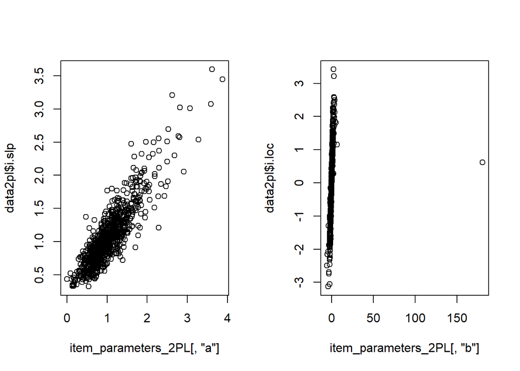

```r
plot(item_parameters_2PL[,"b"], data2pl$i.loc)
```

```r
cor(item_parameters_2PL[,"b"], data2pl$i.loc)
```

```
[1] 0.1923016
```

# boil it down to a prediction task

**Central goal(s)**

- identify subset of items which strongly differentiating between LLMs
- identify subset of items which are not differentiating between LLMs (vice versa)

## simple Decision Trees

Idea motivated by: Goal of the decision tree was to provide a classification to identify and distinguish between biology-derived and technology-derived developments. It aimed to rationalize the discussion about these developments by incorporating descriptive, normative, and emotional aspects, ultimately achieving an average accuracy of 90.0% in classifying the examples (Speck et al. 2017).

- Probably we could get better results using the *Iterative Dichotomiser 3 (ID3) Algorithm*:
  - calculates the entropy of every attribute using the data set S,
  - splits the set S into subsets using the attribute for which entropy is minimum (or, equivalently, information gain is maximum),
  - makes a decision tree node containing that item, and
  - recurs on subsets using remaining attributes.

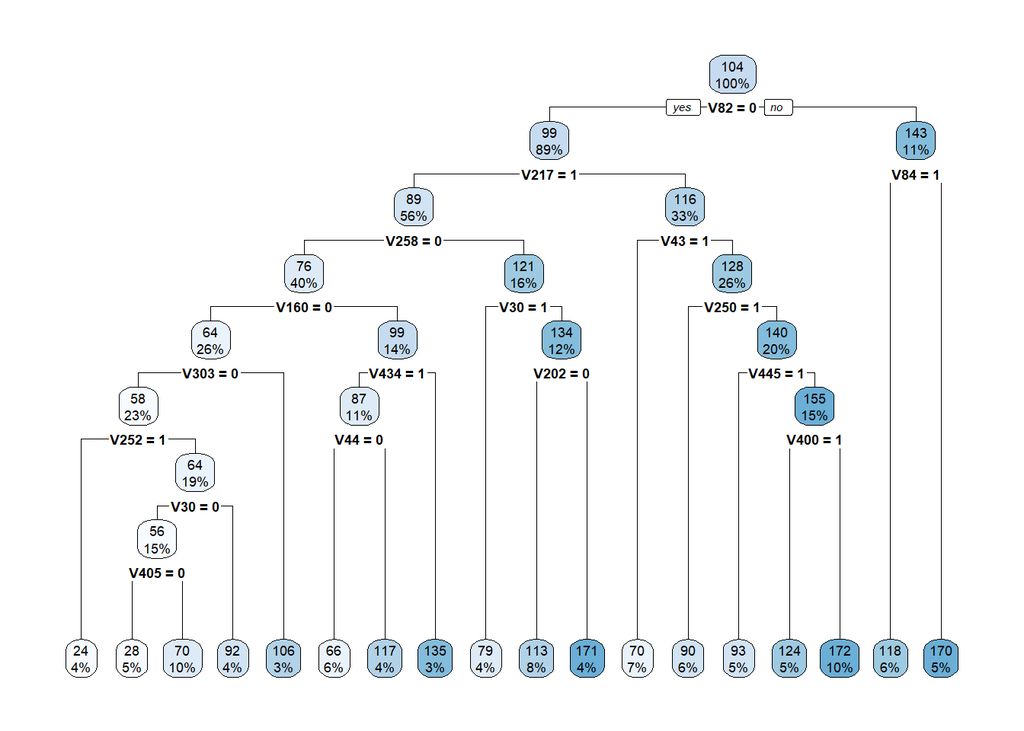

```r
# Create a CART model for classification
set.seed(123)  # for reproducibility
num_cols <- 501

sub_dat <- data_wide[, 1:num_cols]
colnames(sub_dat)[2:ncol(sub_dat)] <- paste0("V", 1:(ncol(sub_dat)-1))
model <- rpart(model_id ~ ., data = sub_dat)
rpart.plot(model)
```

```r
## cross-validation not working, error of predict function:
# train_indices <- sample(1:nrow(data_wide), 0.7 * nrow(data_wide))
# train_data <- data_wide[train_indices, 1:num_cols]
# colnames(train_data)[2:ncol(train_data)] <- paste0("V", 1:(ncol(train_data)-1))
# test_data <- data_wide[-train_indices, 1:num_cols]
# colnames(test_data)[2:ncol(test_data)] <- paste0("V", 1:(ncol(test_data)-1))
# predictions <- predict(model, newdata = test_data, type = "class")
```

## rigid regression, neutral network?

- would address the $p >> n$ problem in our case, we have fewer observations (LLMs) than predictors
  - adds a penalty (alpha) to the regression, which shrinks the coefficients and helps in high-dimensional settings, alpha value determines the strength of this penalty—higher alpha values lead to more regularization
  - necessary to cross-validate result (could also bootstrap as a sensitivity check)

**Literature:**

- for regression models:
  - in R there is a package called **glmnet**, which fits generalized linear and similar models via penalized maximum likelihood, see: https://glmnet.stanford.edu/articles/glmnet.html
- for Structural Equation Models:
  - in R there is a package called **regsem**, which implemented regularization for structural equation models (Jacobucci 2017); tutorial paper (Li, Jacobucci, and Ammerman 2021), guide to select variables (Jacobucci, Brandmaier, and Kievit 2019)
- for Item Response Theory there are **IRTrees**, which are also applied to discover response styles in survey data

# Random stuff

## cite literature in Quarto (rmarkdown)

1. Blah blah (see Yarkoni and Westfall 2017, 33–35; also Speck et al. 2017, ch. 1).
2. Blah blah (Yarkoni and Westfall 2017, 33–35).
3. Blah blah (Yarkoni and Westfall 2017; Speck et al. 2017).
4. Rutkowski et al. says blah (2017).
5. Yarkoni and Westfall (2017) says blah.

# Our ideas

- Zuweisung Items zu inhaltlichen Bereichen: Zuordnung der jeweiligen Items im MMLU zu den inhaltlichen Bereichen; über 50 verschiedene zu sein (Astronomie, Mathe, Geschichte usw.)
- mögl. Ansatz zur Lösung der Schätzprobleme (Simulationsstudie), wäre die “logits, probabilities (nach softmax)” der Antworten zu den Fragen (A-E, …) zu bekommen, um daraus beliebig viele Antworten für alle LLMs zu generieren:
  - Annahme probability vector für (A-C): [.11, .12, .31] $\rightarrow$ Summe bilden: $0.11+0.12+0.31=0.54$ $\rightarrow$ jedes Element durch Summe dividieren: $\frac{.11}{.54} = .2037$ usw. so viele 0, 1 ziehen wir dann

## References

Auerswald, Max, and Morten Moshagen. 2019. “How to Determine the Number of Factors to Retain in Exploratory Factor Analysis: A Comparison of Extraction Methods Under Realistic Conditions.” *Psychological Methods* 24: 468–91. https://doi.org/10.1037/met0000200.

Biemer, Paul P., Edith D. de Leeuw, Stephanie Eckman, Brad Edwards, Frauke Kreuter, Lars E. Lyberg, N. Clyde Tucker, and Brady T. West. 2017. *Total Survey Error in Practice*. John Wiley & Sons.

Bollen, Kenneth A. 2002. “Latent Variables in Psychology and the Social Sciences.” *Annual Review of Psychology* 53 (January): 605–34. https://doi.org/10.1146/annurev.psych.53.100901.135239.

Borsboom, Denny. 2008. “Latent Variable Theory.” *Measurement: Interdisciplinary Research and Perspectives* 6 (1-2): 25–53. https://doi.org/10.1080/15366360802035497.

Cronbach, Lee J., and Paul E. Meehl. 1955. “Construct Validity in Psychological Tests.” *Psychological Bulletin* 52 (4): 281–302. https://doi.org/10.1037/h0040957.

Fligstein, Neil, and Doug McAdam. 2015. *A Theory of Fields*. Oxford University Press.

Groves, Robert M., and Lars Lyberg. 2010. “Total Survey Error: Past, Present, and Future.” *Public Opinion Quarterly* 74 (5): 849–79. https://doi.org/10.1093/poq/nfq065.

Jacobucci, Ross. 2017. “Regsem: Regularized Structural Equation Modeling.” arXiv. https://doi.org/10.48550/arXiv.1703.08489.

Jacobucci, Ross, Andreas M. Brandmaier, and Rogier A. Kievit. 2019. “A Practical Guide to Variable Selection in Structural Equation Modeling by Using Regularized Multiple-Indicators, Multiple-Causes Models.” *Advances in Methods and Practices in Psychological Science* 2 (1): 55–76. https://doi.org/10.1177/2515245919826527.

Konsortium Bundesbericht Wissenschaftlicher Nachwuchs. 2021. *Bundesbericht Wissenschaftlicher Nachwuchs 2021*. DE: wbv Media.

Leek, Jeffery T., and Roger D. Peng. 2015. “What Is the Question?” *Science* 347 (6228): 1314–15. https://doi.org/10.1126/science.aaa6146.

Li, Xiaobei, Ross Jacobucci, and Brooke A. Ammerman. 2021. “Tutorial on the Use of the Regsem Package in R.” *Psych* 3 (4): 579–92. https://doi.org/10.3390/psych3040038.

Luhmann, Niklas. 1987. *Soziale Systeme: Grundriss Einer Allgemeinen Theorie*. Suhrkamp.

Moosbrugger, Helfried, and Augustin Kelava, eds. 2020. *Testtheorie und Fragebogenkonstruktion*. Berlin, Heidelberg: Springer Berlin Heidelberg. https://doi.org/10.1007/978-3-662-61532-4.

Peng, Roger D., and Elizabeth Matsui. 2016. *The Art of Data Science: A Guide for Anyone Who Works with Data*. Lulu.com.

Rahal, Rima-Maria, Susann Fiedler, Adeyemi Adetula, Ronnie P.-A. Berntsson, Ulrich Dirnagl, Gordon B. Feld, Christian J. Fiebach, et al. 2023. “Quality Research Needs Good Working Conditions.” *Nature Human Behaviour* 7 (2): 164–67. https://doi.org/10.1038/s41562-022-01508-2.

Schurig, Michael. 2017. “Latente Variablenmodelle in der empirischen Bildungsforschung - die Schärfe und Struktur der Schatten an der Wand.” PhD thesis, TU Dortmund.

Sengewald, Marie-Ann, Mirka Henninger, Pia Bechtloff, and Veit Kubik. 2024. “Familiengerechte Karrieremöglichkeiten in Der Psychologischen Forschung?” *Psychologische Rundschau* 75 (3): 236–48. https://doi.org/10.1026/0033-3042/a000682.

Skrondal, Anders, and Sophia Rabe-Hesketh. 2004. *Generalized Latent Variable Modeling: Multilevel, Longitudinal, and Structural Equation Models*. New York: Chapman and Hall/CRC. https://doi.org/10.1201/9780203489437.

———. 2007. “Latent Variable Modelling: A Survey*.” *Scandinavian Journal of Statistics* 34 (4): 712–45. https://doi.org/10.1111/j.1467-9469.2007.00573.x.

Speck, Olga, David Speck, Rafael Horn, Johannes Gantner, and Klaus Peter Sedlbauer. 2017. “Biomimetic Bio-Inspired Biomorph Sustainable? An Attempt to Classify and Clarify Biology-Derived Technical Developments.” *Bioinspiration & Biomimetics* 12 (1): 011004. https://doi.org/10.1088/1748-3190/12/1/011004.

Tourangeau, Roger, Lance J. Rips, and Kenneth Rasinski. 2000. *The Psychology of Survey Response*. Cambridge University Press.

Wallerstein, Immanuel Maurice. 2006. *European Universalism: The Rhetoric of Power*. New Press.

Yarkoni, Tal, and Jacob Westfall. 2017. “Choosing Prediction Over Explanation in Psychology: Lessons From Machine Learning.” *Perspectives on Psychological Science* 12 (6): 1100–1122. https://doi.org/10.1177/1745691617693393.